# 特征工程和建模

```python
from IPython.display import HTML
HTML('''<script>
code_show=true;
function code_toggle() {
  if (code_show){
    $(\'div.input\').hide();
  } else {
    $(\'div.input\').show();
  }
  code_show = !code_show
}
$( document ).ready(code_toggle);
</script>
  <form action="javascript:code_toggle()">
    <input type="submit" value="点击此处隐藏/显示代码.">
 </form>''')
```

```python
%config InlineBackend.figure_format='retina'
import pandas as pd
import numpy as np
import warnings
import seaborn as sns
import matplotlib.pyplot as plt
import gc
warnings.filterwarnings('ignore')
plt.rcParams['font.sans-serif'] = ['SimHei']
plt.rcParams['axes.unicode_minus']=False
```

```python
ogdata=pd.read_csv("WA_Fn-UseC_-Telco-Customer-Churn.csv")
pd.set_option('display.max_columns',None)
ogdata
```

|  | customerID | gender | SeniorCitizen | Partner | Dependents | tenure | PhoneService | MultipleLines | InternetService | OnlineSecurity | OnlineBackup | DeviceProtection | TechSupport | StreamingTV | StreamingMovies | Contract | PaperlessBilling | PaymentMethod | MonthlyCharges | TotalCharges | Churn |
| --- | --- | --- | --- | --- | --- | --- | --- | --- | --- | --- | --- | --- | --- | --- | --- | --- | --- | --- | --- | --- | --- |
| 0 | 7590-VHVEG | Female | 0 | Yes | No | 1 | No | No phone service | DSL | No | Yes | No | No | No | No | Month-to-month | Yes | Electronic check | 29.85 | 29.85 | No |
| 1 | 5575-GNVDE | Male | 0 | No | No | 34 | Yes | No | DSL | Yes | No | Yes | No | No | No | One year | No | Mailed check | 56.95 | 1889.5 | No |
| 2 | 3668-QPYBK | Male | 0 | No | No | 2 | Yes | No | DSL | Yes | Yes | No | No | No | No | Month-to-month | Yes | Mailed check | 53.85 | 108.15 | Yes |
| 3 | 7795-CFOCW | Male | 0 | No | No | 45 | No | No phone service | DSL | Yes | No | Yes | Yes | No | No | One year | No | Bank transfer (automatic) | 42.30 | 1840.75 | No |
| 4 | 9237-HQITU | Female | 0 | No | No | 2 | Yes | No | Fiber optic | No | No | No | No | No | No | Month-to-month | Yes | Electronic check | 70.70 | 151.65 | Yes |
| ... | ... | ... | ... | ... | ... | ... | ... | ... | ... | ... | ... | ... | ... | ... | ... | ... | ... | ... | ... | ... | ... |
| 7038 | 6840-RESVB | Male | 0 | Yes | Yes | 24 | Yes | Yes | DSL | Yes | No | Yes | Yes | Yes | Yes | One year | Yes | Mailed check | 84.80 | 1990.5 | No |
| 7039 | 2234-XADUH | Female | 0 | Yes | Yes | 72 | Yes | Yes | Fiber optic | No | Yes | Yes | No | Yes | Yes | One year | Yes | Credit card (automatic) | 103.20 | 7362.9 | No |
| 7040 | 4801-JZAZL | Female | 0 | Yes | Yes | 11 | No | No phone service | DSL | Yes | No | No | No | No | No | Month-to-month | Yes | Electronic check | 29.60 | 346.45 | No |
| 7041 | 8361-LTMKD | Male | 1 | Yes | No | 4 | Yes | Yes | Fiber optic | No | No | No | No | No | No | Month-to-month | Yes | Mailed check | 74.40 | 306.6 | Yes |
| 7042 | 3186-AJIEK | Male | 0 | No | No | 66 | Yes | No | Fiber optic | Yes | No | Yes | Yes | Yes | Yes | Two year | Yes | Bank transfer (automatic) | 105.65 | 6844.5 | No |

7043 rows × 21 columns

```python
data=ogdata.copy()
data=data.drop(['customerID','gender','PhoneService','MultipleLines'],axis=1)
data['TotalCharges']=data['TotalCharges'].apply(pd.to_numeric, errors='coerce')
data['TotalCharges'][data['TotalCharges'].isnull()]=data['MonthlyCharges']
```

```python
def swich(df):
    cateCols = [c for c in df.columns if df[c].dtype == 'object']
    for col in cateCols:
        if df[col].nunique()==2:
            df[col]=df[col].map(lambda x:1 if x=='Yes'else 0)
        else:
            df=pd.get_dummies(df,columns=[col])
    return df
data=swich(data)
data.to_csv('Processed_data.csv',index=None)
```

# 数据预处理

## 正负样本不均

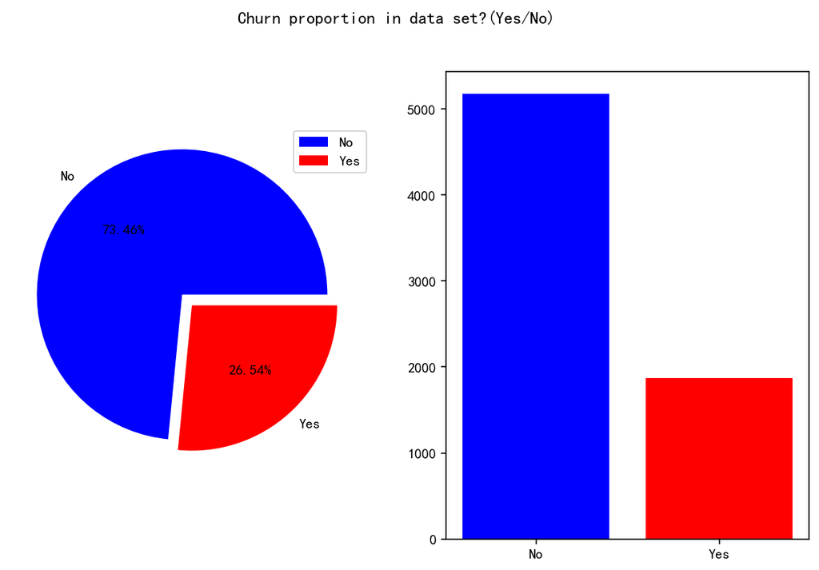

```python
fig=plt.figure(figsize=(10,6))
ax1=plt.subplot(121)
plt.pie(ogdata['Churn'].value_counts(),labels=ogdata['Churn'].value_counts().index,autopct='%1.2f%%',
        colors=['b','r'],explode=(0.1,0))
plt.legend()
ax2=plt.subplot(122)
plt.bar(ogdata['Churn'].value_counts().index.tolist(),ogdata['Churn'].value_counts(),color=['b','r'])
plt.suptitle('Churn proportion in data set?(Yes/No)')
plt.show()
```

## SMOTE

```python
from imblearn.over_sampling import SMOTE
from sklearn.model_selection import train_test_split
prodata=pd.read_csv('Processed_data.csv')
features=prodata.drop(['Churn'],axis=1).values
labels=prodata['Churn'].values
features_train, features_test, labels_train, labels_test = train_test_split(features,
                                                                            labels, test_size=0.4, random_state=0)
oversample=SMOTE(random_state=0)
features_train,labels_train=oversample.fit_sample(features_train,labels_train)
```

## SMOTE之后训练样本分布

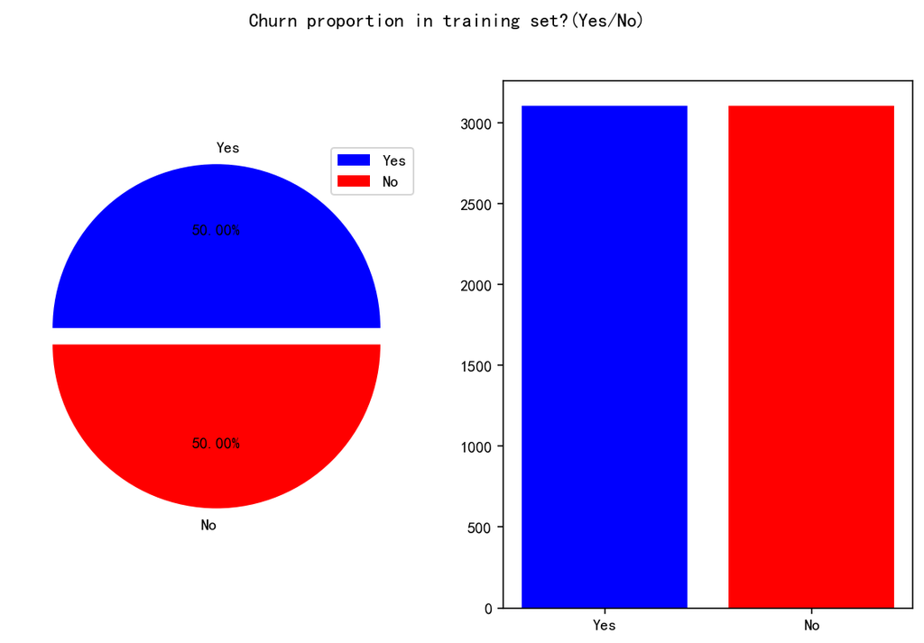

```python
fig=plt.figure(figsize=(10,6))
ax1=plt.subplot(121)
plt.pie(pd.value_counts(labels_train).reset_index()[0],labels=['Yes','No'],autopct='%1.2f%%',
        colors=['b','r'],explode=(0.1,0))
plt.legend()
ax2=plt.subplot(122)
plt.bar(['Yes','No'],pd.value_counts(labels_train).reset_index()[0],color=['b','r'])
plt.suptitle('Churn proportion in training set?(Yes/No)')
plt.show()
```

# 构建模型

管道模型pipeline结构：  
预处理部分：

1. 'skb'使用SelectKBest根据卡方统计量筛选特征经过GridSearchCV得到最佳特征数32
2. 'scaler'再使用StandardScaler(),对数据进行标准化

分类器部分:  
由一个投票分类器为主体,其中包括三个分类器,分别为:一个随机森林分类器——'rfr'和两个Bagging分类器'baggtree'和'bagglog'，baggtree是以决策树为基，bagglog是以逻辑回归为基,投票分类方式为soft,  
即将所有模型预测样本为某一类别的概率的平均值作为标准，概率最高的对应的类型为最终的预测结果

## 找合适参数

用GridSearchCV找基分类器RandomForestClassifier,DecisionTreeClassifier,LogisticRegression的参数  
再通过GridSearchCV找到两个BaggingClassifier的参数

### 找逻辑回归合适的参数

```python
from sklearn.svm import l1_min_c
from sklearn.model_selection import cross_val_score
from sklearn.linear_model import LogisticRegression
cs = l1_min_c(features_train, labels_train, loss='log') * np.logspace(5,7)
```

```python
logbase = LogisticRegression(penalty='l1',solver='liblinear')
k_scores_mean=[]
k_scores_std=[]
for c in cs:
    logbase.set_params(C=c)
    logbase.fit(features_train,labels_train)
    scores = cross_val_score(logbase,features_test, labels_test, cv=5, scoring='roc_auc')  #http://scikit-learn.org/stable/modules/model_evaluation.html
    k_scores_mean.append(scores.mean())
    k_scores_std.append(scores.std())
```

#### 找到合适的C

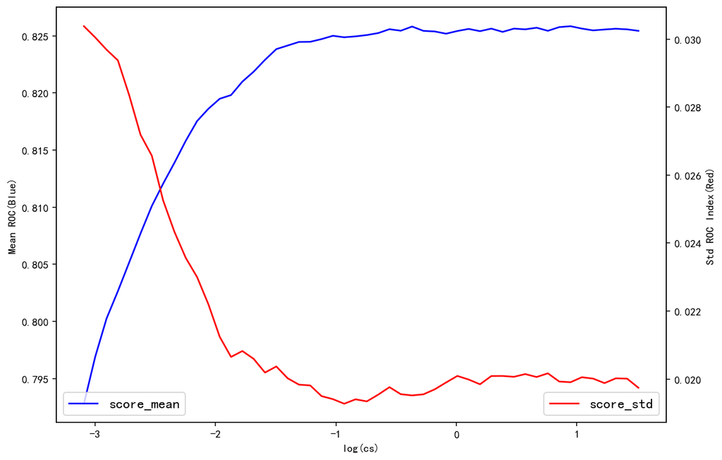

```python
fig = plt.figure(figsize=(10,7))
ax1 = fig.add_subplot(111)
ax1.plot(np.log(cs), k_scores_mean,'b')
ax1.set_ylabel('Mean ROC(Blue)')
ax1.set_xlabel('log(cs)')
ax1.legend(["score_mean"],fontsize=13,loc='lower left')
ax2 = ax1.twinx()
ax2.plot(np.log(cs), k_scores_std,'r')
ax2.set_ylabel('Std ROC Index(Red)')
ax2.legend(["score_std"],fontsize=13,loc='lower right')
plt.show()
```

找到C的取值在e^1.5左右比较合适  
同时考虑到预测出流失的重要性比较大，因此class_weight参数中增大对流失的权重

### 使用GridSearchCV找到其他分类器合适参数

```python
from sklearn.model_selection import GridSearchCV
from sklearn.linear_model import LogisticRegression
from sklearn.ensemble import BaggingClassifier,RandomForestClassifier
from sklearn.tree import DecisionTreeClassifier
from sklearn.feature_selection import SelectKBest
from sklearn.feature_selection import chi2
from sklearn.preprocessing import StandardScaler
classifiers1=[RandomForestClassifier(criterion='gini',random_state=2020,),
            DecisionTreeClassifier(criterion='gini',random_state=2020),
            LogisticRegression(C=np.exp(1.5),solver='liblinear',random_state=2020,penalty='l1'
                               ,class_weight={0:0.4,1:0.6},n_jobs=-1)]
classifier_names1=['rfr',
                  'tree','logreg']
classifier_param_grid1=[{'rfr__max_leaf_nodes':[68,69,70,71,72],#69
                        'rfr__n_estimators': [130,160,190],#130
                         'rfr__min_samples_split':[50,55,60]#60
                       },
                       {'tree__max_leaf_nodes':[160,190,210],#160
                       'tree__min_samples_split':[5,6,7]}#5
                           ]
classifiers2=[
           BaggingClassifier(DecisionTreeClassifier(criterion='gini',random_state=2020,
   max_depth=6,max_leaf_nodes=60),random_state=1,oob_score=True,bootstrap=True ),
           BaggingClassifier(LogisticRegression(C=np.exp(1.5),solver='liblinear',random_state=2020,penalty='l1'
                               ,class_weight={0:0.4,1:0.6},n_jobs=-1),n_estimators=80)
]
classifier_names2=['baggtree',
                  'bagglog'
                  ]
classifier_param_grid2=[{'baggtree__n_estimators':[79,80,81],
                         'baggtree__max_features':[0.39,0.4,0.41],
                         'baggtree__max_samples':[0.39,0.4,0.41]},
                       {'bagglog__n_estimators':[20,50,80],
                        'bagglog__max_features':[0.6,0.7,0.8],
                        'bagglog__max_samples':[0.6,0.7,0.8]}
                      ]
```

```python
def GridSearchCV_work(pipeline,train_x,train_y,test_x,test_y,param_grid,score='accuracy_score'):
    gridsearch=GridSearchCV(estimator=pipeline,param_grid=param_grid,cv=3,scoring=score)
    search=gridsearch.fit(train_x,train_y)
    print('最优参数:',search.best_params_)
    print('最优分数: %0.4lf'%search.best_score_)
    predict_y=gridsearch.predict(test_x)
    print(" 准确率 %0.4lf"%accuracy_score(test_y,predict_y))
for model,model_name,model_param_grid in zip(classifiers2,classifier_names2,classifier_param_grid2):
    pipeline=Pipeline([('scaler',StandardScaler()),#('pca',PCA),
        (model_name,model)])
    GridSearchCV_work(pipeline,features_train,labels_train,features_test,labels_test,
                             model_param_grid,score='accuracy')
```

[output not shown]

# 模型效果

```python
from sklearn.ensemble import VotingClassifier
from sklearn.pipeline import Pipeline
from sklearn.decomposition import PCA
from sklearn.svm import SVC
pipeline=Pipeline([
    ('skb',SelectKBest(chi2, k=32)),
    ('scaler',StandardScaler()),
    ('vote',VotingClassifier(estimators=[
         ('rfr',RandomForestClassifier(criterion='gini',random_state=2020
        ,max_leaf_nodes=69,n_estimators=130,min_samples_split=60)),
         ('baggtree',BaggingClassifier(DecisionTreeClassifier(criterion='gini',
        ),random_state=1,n_estimators=100, max_samples=0.4,
                               max_features=0.4,oob_score=True,bootstrap=True, n_jobs=-1)),
        ("bagglog",BaggingClassifier(LogisticRegression(C=np.exp(1.9),solver='liblinear',
                                    penalty='l1',class_weight={0:0.75,1:0.25},n_jobs=-1),
                random_state=1))],voting="soft"))])
pipeline.fit(features_train,labels_train)
#pipeline.score(features_test,labels_test)
print('模型训练成功')
```

```
模型训练成功
```

## 定义效果展示函数

```python
from sklearn.metrics import accuracy_score
from sklearn.metrics import classification_report,roc_curve,auc,accuracy_score
def model_test_information(model,features_test,labels_test):
    tarin_pred=model.predict(features_train)
    tarin_pro=model.predict_proba(features_train)
    test_pred=model.predict(features_test)
    test_pro=model.predict_proba(features_test)
    fpr1,tpr1,thresholds1= roc_curve(labels_train,tarin_pro[:,1])
    fpr2,tpr2,thresholds2= roc_curve(labels_test,test_pro[:,1])
    plt.figure(figsize=(10,6))
    lw = 2
    roc_auc1 = auc(fpr1,tpr1)
    roc_auc2 = auc(fpr2,tpr2)
    ax1=plt.subplot(121)
    plt.plot(fpr1, tpr1, color='darkorange',lw=lw,
             label='ROC curve (area = %0.5f)' % roc_auc1)
    plt.plot([0,1], [0,1], color='navy', lw=lw, linestyle='--')
    plt.xlim([0, 1.0])
    plt.ylim([0, 1.05])
    plt.xlabel('False Positive Rate')
    plt.ylabel('True Positive Rate')
    plt.legend(loc="lower right")
    plt.title('训练集')
    ax2=plt.subplot(122)
    plt.plot(fpr2, tpr2, color='darkorange',lw=lw,
             label='ROC curve (area = %0.5f)' % roc_auc2)
    plt.plot([0,1], [0,1], color='navy', lw=lw, linestyle='--')
    plt.xlim([0, 1.0])
    plt.ylim([0, 1.05])
    plt.xlabel('False Positive Rate')
    plt.ylabel('True Positive Rate')
    plt.title('测试集')
    plt.suptitle('ROC曲线')
    plt.legend(loc="lower right")
    plt.show()
    print('训练集acc={:4}          测试集acc={}'.format(round(accuracy_score(labels_train,tarin_pred),4),
                                         round(accuracy_score(labels_test,test_pred),4)))
    print('训练集{}'.format(classification_report(labels_train,tarin_pred)))
    print('测试集{}'.format(classification_report(labels_test,test_pred)))
```

## 最终效果

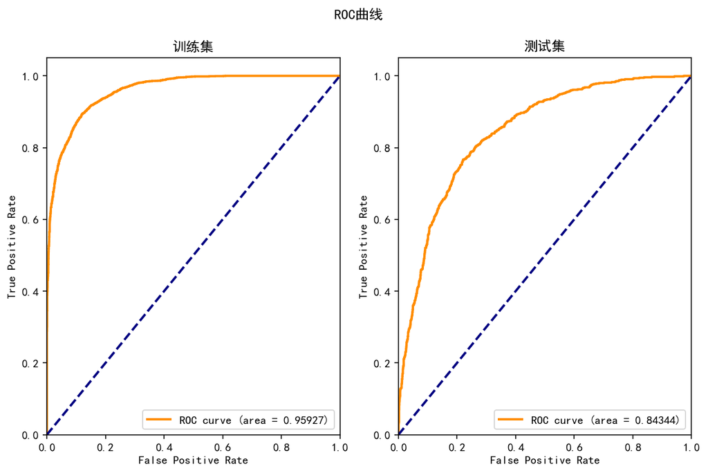

```
训练集acc=0.8803          测试集acc=0.8101
训练集              precision    recall  f1-score   support

           0       0.86      0.91      0.88      3103
           1       0.91      0.85      0.88      3103

    accuracy                           0.88      6206
   macro avg       0.88      0.88      0.88      6206
weighted avg       0.88      0.88      0.88      6206

测试集              precision    recall  f1-score   support

           0       0.85      0.89      0.87      2071
           1       0.66      0.58      0.62       747

    accuracy                           0.81      2818
   macro avg       0.76      0.74      0.75      2818
weighted avg       0.80      0.81      0.81      2818
```

```python
model_test_information(pipeline,features_test,labels_test)
```

# 总结